# 12_canoe_river_degs

## 12_canoe_river_degs

#### Question

1. A canoe travels 1.3 m/s **relative to the water**. A river, heading east, flows at 1.9 m/s. The canoe points at a direction 145° counterclockwise from east.

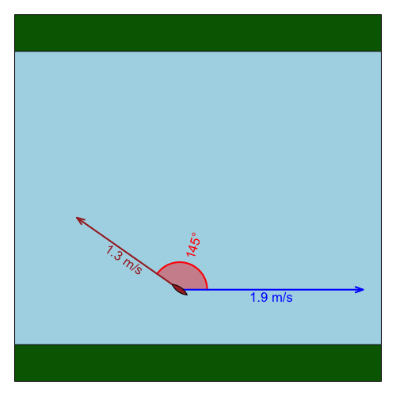

   Find the canoe’s total speed, in m/s, and direction of travel, as degrees counterclockwise from east. (In other words, find the canoe’s velocity **relative to the ground**, in polar form.)
   - Speed =
   - Direction =

#### Question

2. A canoe travels 1.7 m/s **relative to the water**. A river, heading east, flows at 2.1 m/s. The canoe points at a direction 130° counterclockwise from east.

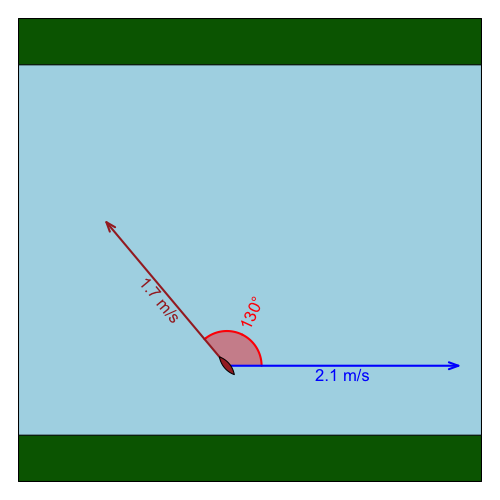

   Find the canoe’s total speed, in m/s, and direction of travel, as degrees counterclockwise from east. (In other words, find the canoe’s velocity **relative to the ground**, in polar form.)
   - Speed =
   - Direction =

#### Question

3. A canoe travels 2.3 m/s **relative to the water**. A river, heading east, flows at 2.5 m/s. The canoe points at a direction 55° counterclockwise from east.

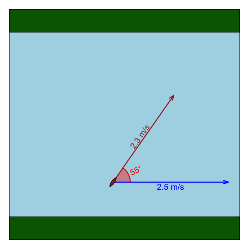

   Find the canoe’s total speed, in m/s, and direction of travel, as degrees counterclockwise from east. (In other words, find the canoe’s velocity **relative to the ground**, in polar form.)
   - Speed =
   - Direction =

#### Question

4. A canoe travels 3.0 m/s **relative to the water**. A river, heading east, flows at 2.0 m/s. The canoe points at a direction 50° counterclockwise from east.

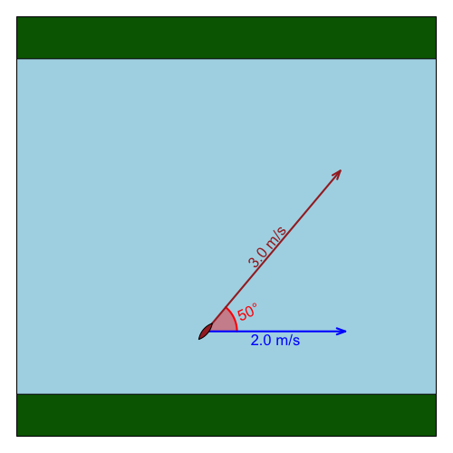

   Find the canoe’s total speed, in m/s, and direction of travel, as degrees counterclockwise from east. (In other words, find the canoe’s velocity **relative to the ground**, in polar form.)
   - Speed =
   - Direction =

#### Question

5. A canoe travels 2.1 m/s **relative to the water**. A river, heading east, flows at 1.3 m/s. The canoe points at a direction 83° counterclockwise from east.

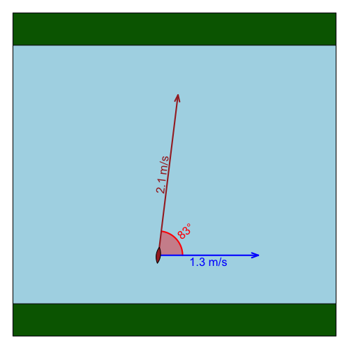

   Find the canoe’s total speed, in m/s, and direction of travel, as degrees counterclockwise from east. (In other words, find the canoe’s velocity **relative to the ground**, in polar form.)
   - Speed =
   - Direction =

#### Question

6. A canoe travels 2.8 m/s **relative to the water**. A river, heading east, flows at 3.4 m/s. The canoe points at a direction 38° counterclockwise from east.

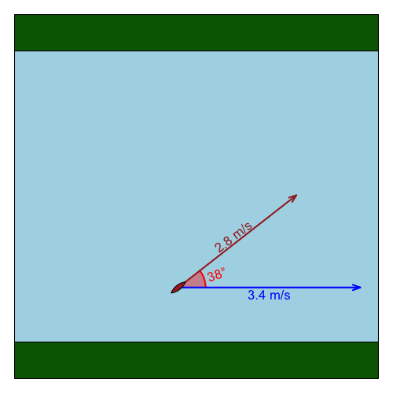

   Find the canoe’s total speed, in m/s, and direction of travel, as degrees counterclockwise from east. (In other words, find the canoe’s velocity **relative to the ground**, in polar form.)
   - Speed =
   - Direction =

#### Question

7. A canoe travels 2.2 m/s **relative to the water**. A river, heading east, flows at 1.7 m/s. The canoe points at a direction 108° counterclockwise from east.

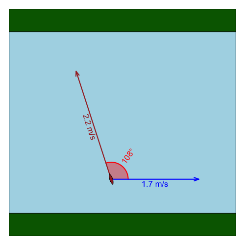

   Find the canoe’s total speed, in m/s, and direction of travel, as degrees counterclockwise from east. (In other words, find the canoe’s velocity **relative to the ground**, in polar form.)
   - Speed =
   - Direction =

#### Question

8. A canoe travels 2.7 m/s **relative to the water**. A river, heading east, flows at 3.0 m/s. The canoe points at a direction 75° counterclockwise from east.

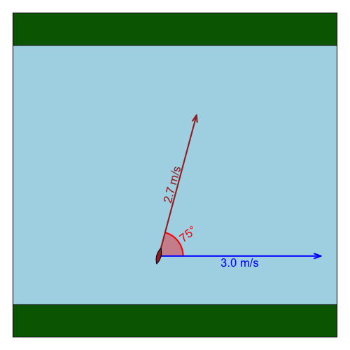

   Find the canoe’s total speed, in m/s, and direction of travel, as degrees counterclockwise from east. (In other words, find the canoe’s velocity **relative to the ground**, in polar form.)
   - Speed =
   - Direction =